# Méthodes des différences de différences

Tany Vao/Atelier 2 : Évaluation d’impact de politiques et de projets

Florent Bédécarrats, Ingrid Dallmann, Diamondra Ramiandrisoa & Melvin Wong

19/06/2026

## Problème de départ

Est-ce que le statut d’aire protégée a un impact sur le couvert forestier ?

On voudrait connaître :

$$ATT = \mathbb{E}[CF^1 \mid AP = 1] - \mathbb{E}[CF^0 \mid AP = 1]$$

avec :

- $CF^1$ : couvert forestier si la zone est protégée ;
- $CF^0$ : couvert forestier si la même zone n’est pas protégée ;
- $AP = 1$ : zone effectivement protégée.

Le problème est qu’on n’observe jamais simultanément les deux états pour la même zone au même moment.

## Le contrefactuel manquant

La question empirique devient :

> Quel aurait été le couvert forestier des zones protégées si elles n’avaient pas été protégées ?

Deux comparaisons simples sont tentantes :

- comparer des zones protégées et non protégées au même moment ;
- comparer les mêmes zones avant et après leur protection.

Chacune de ces comparaisons peut être biaisée.

## Comparer des espaces différents ?

| Espace | Couvert forestier |
| --- | --- |
| Makay | $CF_M = M + AP$ |
| Autre | $CF_A = A$ |

$M$ et $A$ représentent les caractéristiques propres à chaque espace.

Différence observée :

$$CF_M - CF_A = AP + (M - A)$$

On veut isoler $AP$, mais on capte aussi $(M-A)$.

$\Rightarrow$ **Biais de sélection** lié aux différences structurelles entre zones.

## Comparer avant et après ?

| Espace | Temps | Couvert forestier |
| --- | --- | --- |
| Makay | Avant | $CF_{av} = M$ |
| Makay | Après | $CF_{ap} = M + T + AP$ |

$T$ représente les facteurs temporels qui influencent le couvert forestier.

Différence observée :

$$CF_{ap} - CF_{av} = T + AP$$

On veut isoler $AP$, mais on capte aussi $T$.

$\Rightarrow$ **Biais temporel** si d’autres facteurs changent sur la période.

## Principe de la double différence

La méthode combine les deux comparaisons :

- une différence dans le temps pour les zones traitées ;
- une différence dans le temps pour les zones de contrôle ;
- puis la différence entre ces deux évolutions.

$$DiD = (Y_{T,après} - Y_{T,avant}) - (Y_{C,après} - Y_{C,avant})$$

L’évolution du groupe de contrôle sert à approximer ce qui se serait passé pour le groupe traité en l’absence de traitement.

## Exemple stylisé

| Espace | Avant | Après | Évolution |
| --- | --- | --- | --- |
| Makay | $M$ | $M + T + AP$ | $T + AP$ |
| Autre | $A$ | $A + T$ | $T$ |

La double différence donne :

$$(T + AP) - T = AP$$

L’idée est de retirer à l’évolution des zones protégées l’évolution observée dans des zones comparables non protégées.

## Illustration graphique

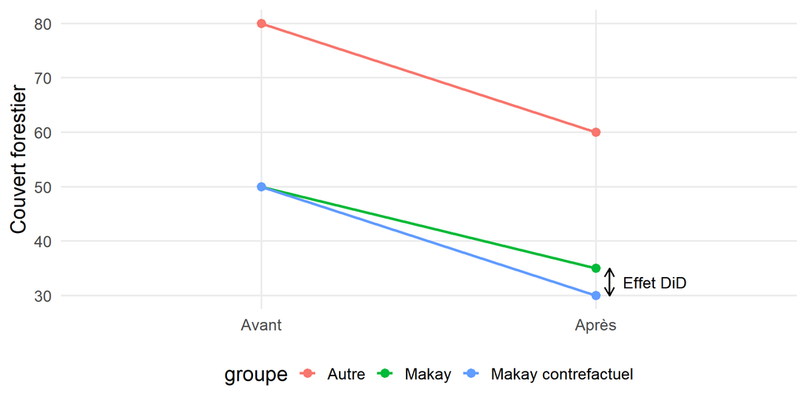

Principe de la double différence

## Interprétation graphique

Dans cette illustration :

- la ligne du groupe de contrôle décrit la tendance temporelle commune ;
- la ligne contrefactuelle prolonge cette tendance pour Makay ;
- l’écart entre Makay observé et Makay contrefactuel après traitement est l’effet estimé.

La méthode ne suppose pas que les niveaux initiaux soient identiques.

Elle suppose que les évolutions auraient été comparables en l’absence du traitement.

## Hypothèses centrales

La différence en différence repose principalement sur deux hypothèses.

**Tendances parallèles**

En l’absence du traitement, le groupe traité et le groupe de contrôle auraient connu la même évolution moyenne.

**Composition stable**

Les groupes comparés doivent être définis de manière stable entre les périodes.

Ces hypothèses sont des conditions de crédibilité, pas seulement des détails techniques.

## Tendances parallèles

Formellement, pour les unités traitées et non traitées :

$$\mathbb{E}[Y^0_{après} - Y^0_{avant} \mid T = 1]
=
\mathbb{E}[Y^0_{après} - Y^0_{avant} \mid T = 0]$$

Autrement dit, sans aire protégée, le couvert forestier des zones protégées aurait suivi la même tendance que celui des zones non protégées utilisées comme contrôle.

## Peut-on vérifier cette hypothèse ?

On ne peut pas la tester directement, car on n’observe pas le contrefactuel.

On peut seulement chercher des éléments de plausibilité :

- comparer les tendances avant le traitement ;
- faire des tests placebo autour d’une fausse date de traitement ;
- tester la robustesse avec d’autres groupes de contrôle ;
- expliquer pourquoi les deux groupes devraient avoir été soumis aux mêmes chocs temporels.

## Tendances prétraitement cohérentes

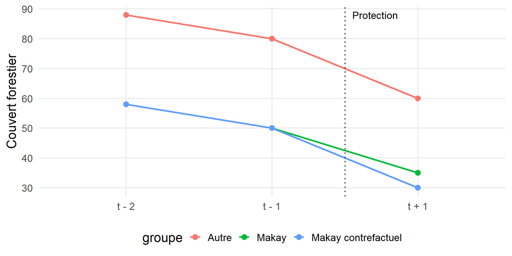

Cas favorable : tendances prétraitement compatibles avec l’hypothèse

## Tendances prétraitement divergentes

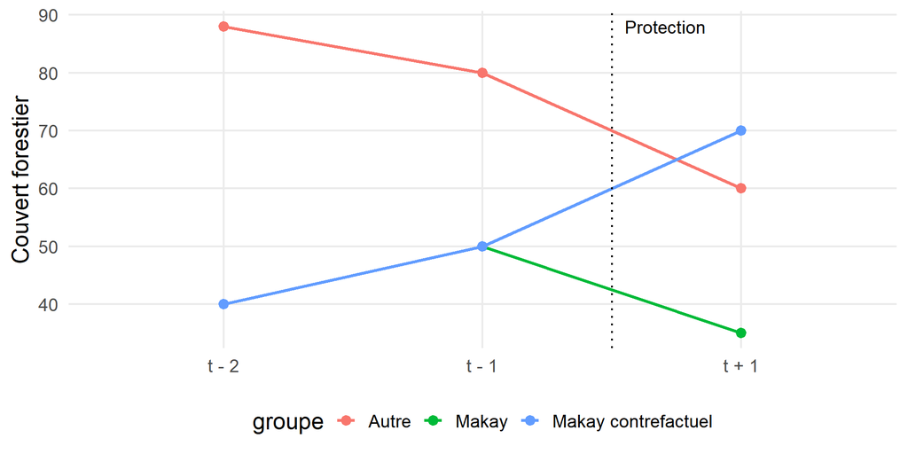

Cas défavorable : les tendances prétraitement divergent

## Composition stable

La composition des groupes doit rester comparable entre les périodes.

Exemples de problèmes possibles :

- les zones traitées ou contrôles ne sont pas les mêmes avant et après ;
- les ménages enquêtés changent de manière sélective ;
- la définition du traitement change au cours du temps ;
- certaines unités disparaissent de l’échantillon pour des raisons liées au traitement.

$\Rightarrow$ Ce risque est particulièrement important avec des coupes transversales répétées.

## Deux types de données possibles

Pour mettre en œuvre une double différence, il faut au moins deux observations dans le temps.

**Données de panel**

Les mêmes unités sont observées avant et après.

**Coupes transversales répétées**

On observe des échantillons comparables tirés dans les mêmes populations, mais pas nécessairement les mêmes unités.

Dans les deux cas, il faut être explicite sur ce que signifie la stabilité des groupes.

## Formalisation

Supposons :

- $Y^1_{it}$ : résultat de l’unité $i$ à la date $t$ si elle est traitée ;
- $Y^0_{it}$ : résultat de l’unité $i$ à la date $t$ si elle n’est pas traitée.

L’hypothèse centrale de la DiD est que, en l’absence du traitement, le résultat moyen des unités traitées aurait suivi :

$$\mathbb{E}[Y^0_{it} \mid T_i = 1] = \beta_i + \gamma_t$$

Les différences fixes entre unités sont absorbées par $\beta_i$ ; les tendances communes sont absorbées par $\gamma_t$.

## Variables de traitement et de période

On définit :

$$Treat_i =
\begin{cases}
1 & \text{si l'unité est traitée} \\
0 & \text{sinon}
\end{cases}$$

$$Post_t =
\begin{cases}
1 & \text{après le traitement} \\
0 & \text{avant le traitement}
\end{cases}$$

L’interaction $Treat_i \times Post_t$ identifie les unités traitées après le traitement.

## Estimation par régression

Le modèle canonique à deux groupes et deux périodes s’écrit :

$$Y_{it} = \alpha + \beta Treat_i + \gamma Post_t
+ \lambda (Treat_i \times Post_t) + \varepsilon_{it}$$

Le coefficient $\lambda$ est l’estimateur de différence en différence.

Il mesure l’évolution supplémentaire des unités traitées après le traitement, relativement à l’évolution du groupe de contrôle.

## Pourquoi l’interaction donne la DiD ?

| Groupe | Période | Espérance conditionnelle |
| --- | --- | --- |
| Contrôle | Avant | $\alpha$ |
| Contrôle | Après | $\alpha + \gamma$ |
| Traité | Avant | $\alpha + \beta$ |
| Traité | Après | $\alpha + \beta + \gamma + \lambda$ |

Donc :

$$[(\alpha + \beta + \gamma + \lambda) - (\alpha + \beta)]
-
[(\alpha + \gamma) - \alpha]
= \lambda$$

## Implémentation minimale en R

```
(Intercept)       treat        post  treat:post
         80         -30         -20           5
```

Le coefficient `treat:post` correspond à l’estimation DiD.

## Choisir un groupe de contrôle

Le groupe de contrôle doit être crédible comme trajectoire contrefactuelle.

Deux stratégies fréquentes :

- utiliser une expérience naturelle ou une règle d’assignation suffisamment exogène ;
- construire un groupe comparable, par exemple par appariement sur des caractéristiques observables.

L’appariement ne remplace pas l’hypothèse de tendances parallèles.

Il peut rendre cette hypothèse plus plausible si les variables utilisées sont pertinentes.

## Ce qu’il faut documenter

Pour une analyse DiD appliquée, il faut clarifier :

- la date de traitement ;
- la définition exacte des unités traitées ;
- la construction du groupe de contrôle ;
- les périodes disponibles avant et après ;
- les risques de changement de composition ;
- les preuves indirectes en faveur des tendances parallèles.

## Résumé

Pour mettre en œuvre une double différence, il faut :

- au moins deux périodes ;
- au moins deux groupes ;
- une définition stable du traitement ;
- un groupe de contrôle permettant de construire une trajectoire contrefactuelle crédible.

La formule est simple. La difficulté est de justifier le contrefactuel.

## Résumé

La crédibilité de l’estimation repose surtout sur l’hypothèse de tendances parallèles en l’absence du traitement.

Cette hypothèse n’est pas vérifiable directement.

Elle doit être défendue par :

- la connaissance du contexte ;
- les tendances prétraitement ;
- des tests placebo ;
- des analyses de robustesse.

# Annexe : quelques précautions récentes

## Traitements à dates différentes

La présentation principale correspond au cas le plus simple : deux groupes et deux périodes.

Dans beaucoup d’applications, les unités sont traitées à des dates différentes.

Exemple : des aires protégées créées en 2003, 2008, 2015 et 2020.

Dans ce cas, la question n’est plus seulement « traité versus contrôle », mais aussi :

> Qui sert de contrôle pour qui, et à quelle date ?

## Effets hétérogènes

Si l’effet du traitement varie selon les groupes ou selon le temps depuis le traitement, certains estimateurs standards avec effets fixes peuvent devenir difficiles à interpréter.

Le problème n’est pas que la DiD serait inutilisable.

Le problème est que l’estimation peut mélanger plusieurs comparaisons, dont certaines ne correspondent pas au contrefactuel que l’on souhaite défendre.

Il faut donc éviter de traiter le coefficient comme une boîte noire.

## Que faire en pratique ?

Quand les traitements arrivent à des dates différentes, il est préférable de :

- expliciter les cohortes de traitement ;
- montrer les tendances avant traitement ;
- utiliser des graphiques d’événement avec prudence ;
- choisir un estimateur adapté aux traitements échelonnés si nécessaire ;
- dire clairement quels groupes servent de comparaison.

Pour cette formation, l’idée centrale reste la même : la crédibilité d’une DiD dépend moins de la formule que de la qualité du contrefactuel construit.